# **✨ Red Wine Quality Prediction ✨**

# **🧠 Basic Understanding of Data 🧠**

### 1. Cheking Dimension of Dataset.

```python
df.shape
```

```
(1599, 12)
```

### 📊 Inference:

- There are total **1599 Records/Rows** in the dataset.
- There are total **12 Features/columns** in the dataset.

### 2. Generating Basic Information about Data.

```python
df.info(verbose=False)
```

```
<class 'pandas.core.frame.DataFrame'>
RangeIndex: 1599 entries, 0 to 1598
Columns: 12 entries, fixed acidity to quality
dtypes: float64(11), int64(1)
memory usage: 150.0 KB
```

### 📊 Inference:

- All the **features** present is in the dataset is **numerical.**
- No **Categorical Features** present in the dataset.

### 3. Computing Total No. of Missing Values & Percentage of Missing values.

```python
null_df = df.isnull().sum().to_frame().rename(columns={0:"Total No. of Missing Values"})
null_df["% of Missing values"] = round(100*null_df["Total No. of Missing Values"]/len(df),2)
null_df.sort_values(by="% of Missing values",ascending=False)
```

|  | Total No. of Missing Values | % of Missing values |
| --- | --- | --- |
| fixed acidity | 0 | 0.0 |
| volatile acidity | 0 | 0.0 |
| citric acid | 0 | 0.0 |
| residual sugar | 0 | 0.0 |
| chlorides | 0 | 0.0 |
| free sulfur dioxide | 0 | 0.0 |
| total sulfur dioxide | 0 | 0.0 |
| density | 0 | 0.0 |
| pH | 0 | 0.0 |
| sulphates | 0 | 0.0 |
| alcohol | 0 | 0.0 |
| quality | 0 | 0.0 |

### 📊 Inference:

- **None of the features** is hvaing **missing values.**
- So we can say the dataset will be more reliable for prediction wine quality.

### 4. Checking Presence of Duplicate Records in Dataset.

```python
print("Is there any Duplicate Records => ",df.duplicated().any())
print("-"*42)
print("Total Duplicate Records present is =>",df[df.duplicated()==True].shape[0])
```

```
Is there any Duplicate Records =>  True
------------------------------------------
Total Duplicate Records present is => 240
```

### 💬 Inference:

- The **first output** is **True** which indicates that is **presenece of Duplicate Records.**
- The **second output** is **240** which indicates that there is total **240 Duplicate Records.**
- Duplicate vlaues can lead to **Data Integrity issues** so it's better to **drop these records.**

### 5. Dropping Duplicate Records.

```python
df.drop_duplicates(inplace=True)
```

### 6. Performing Descriptive Statistical Analysis on Numerical Features.

```python
df.describe().T.style.set_properties(**{'background-color': '#E9F6E2','color': 'black','border-color': '#8b8c8c'})
```

|  | count | mean | std | min | 25% | 50% | 75% | max |
| --- | --- | --- | --- | --- | --- | --- | --- | --- |
| fixed acidity | 1359.000000 | 8.310596 | 1.736990 | 4.600000 | 7.100000 | 7.900000 | 9.200000 | 15.900000 |
| volatile acidity | 1359.000000 | 0.529478 | 0.183031 | 0.120000 | 0.390000 | 0.520000 | 0.640000 | 1.580000 |
| citric acid | 1359.000000 | 0.272333 | 0.195537 | 0.000000 | 0.090000 | 0.260000 | 0.430000 | 1.000000 |
| residual sugar | 1359.000000 | 2.523400 | 1.352314 | 0.900000 | 1.900000 | 2.200000 | 2.600000 | 15.500000 |
| chlorides | 1359.000000 | 0.088124 | 0.049377 | 0.012000 | 0.070000 | 0.079000 | 0.091000 | 0.611000 |
| free sulfur dioxide | 1359.000000 | 15.893304 | 10.447270 | 1.000000 | 7.000000 | 14.000000 | 21.000000 | 72.000000 |
| total sulfur dioxide | 1359.000000 | 46.825975 | 33.408946 | 6.000000 | 22.000000 | 38.000000 | 63.000000 | 289.000000 |
| density | 1359.000000 | 0.996709 | 0.001869 | 0.990070 | 0.995600 | 0.996700 | 0.997820 | 1.003690 |
| pH | 1359.000000 | 3.309787 | 0.155036 | 2.740000 | 3.210000 | 3.310000 | 3.400000 | 4.010000 |
| sulphates | 1359.000000 | 0.658705 | 0.170667 | 0.330000 | 0.550000 | 0.620000 | 0.730000 | 2.000000 |
| alcohol | 1359.000000 | 10.432315 | 1.082065 | 8.400000 | 9.500000 | 10.200000 | 11.100000 | 14.900000 |
| quality | 1359.000000 | 5.623252 | 0.823578 | 3.000000 | 5.000000 | 6.000000 | 6.000000 | 8.000000 |

### 💬 Inference:

1. The **minimum wine quality is 3** and the **maximum wine quality is 8.**
2. The **average alchol** a red wine holds according to the data is **10.4**.
3. There a **huge difference** between **average total sulfur dioxide** and **maximum total sulfur dioxide**.

# **📊 Exploratory Data Analysis.📊**

## 1. Visualizing the Target Variable

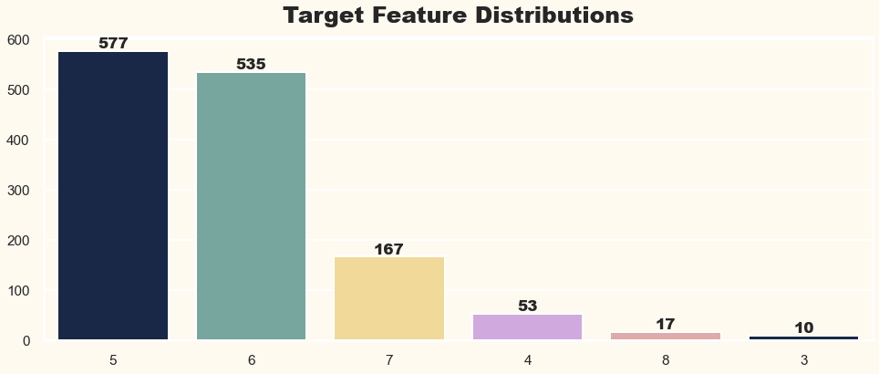

```python
plt.figure(figsize=(13.7,6))
z = df["quality"].value_counts()
sns.barplot(x=z.index, y=z.values, order=z.index, palette=["#11264e","#6faea4","#FEE08B","#D4A1E7","#E7A1A1"])
plt.title("Target Feature Distributions",fontweight="black",size=25,pad=15)
for index,value in enumerate(z.values):
    plt.text(index,value,value, ha="center", va="bottom",fontweight="black")

plt.tight_layout()
plt.show()
```

### 💬 Inference:

- Most of the wines are having quality of **5 or 6**.
- We can clearly observe a **class-imbalance** in the target feature.
- To **overcome** the class-imbalance we can use techniques like:-
  1. **`SMOTE (synthetic minority oversampling technique).`**
  2. **`Stratified K-Folds cross-validation.`**
- **Note:** In this project I have use **Stratified K-Fold Cross-Validaton.**

## 2. Visualizing "Fixed Acidity" Attribute.

```python
def numerical_plot(column):
    plt.figure(figsize=(13.5,10))
    plt.subplot(2,1,1)
    sns.boxplot(x="quality",y=column, data=df, palette=["#FFA07A","#D4A1E7","#FFC0CB","#87CEFA","#F08080","#D8BFD8"])
    plt.title(f"{column.title()} vs Quality Analysis",fontweight="black",size=25,pad=10,)

    plt.subplot(2,1,2)
    sns.histplot(x=column,kde=True,hue="quality",data=df, palette="Set2")
    skew = df[column].skew()
    plt.title(f"Skewness of {column.title()} Feature is: {round(skew,3)}",fontweight="black",size=20,pad=10)
    plt.tight_layout()
    plt.show()
```

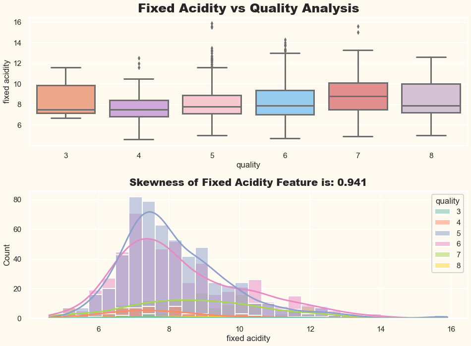

```python
numerical_plot("fixed acidity")
```

### 💬 Inference:

- The feature **fixed acidity** is having **almost a symmetric distribution** but the distribution is **little right skewed** with a skewness value of **0.941**.
- Skewness can lead to several implications like **model performance**, **hypothesis testing** and it returns **biased estimation.**
- So we will use **tranformation techniques** to transform thesse feature to have a **symmetric distribution.**

## 3. Visualizing "Volatile Acidity" Attribute.

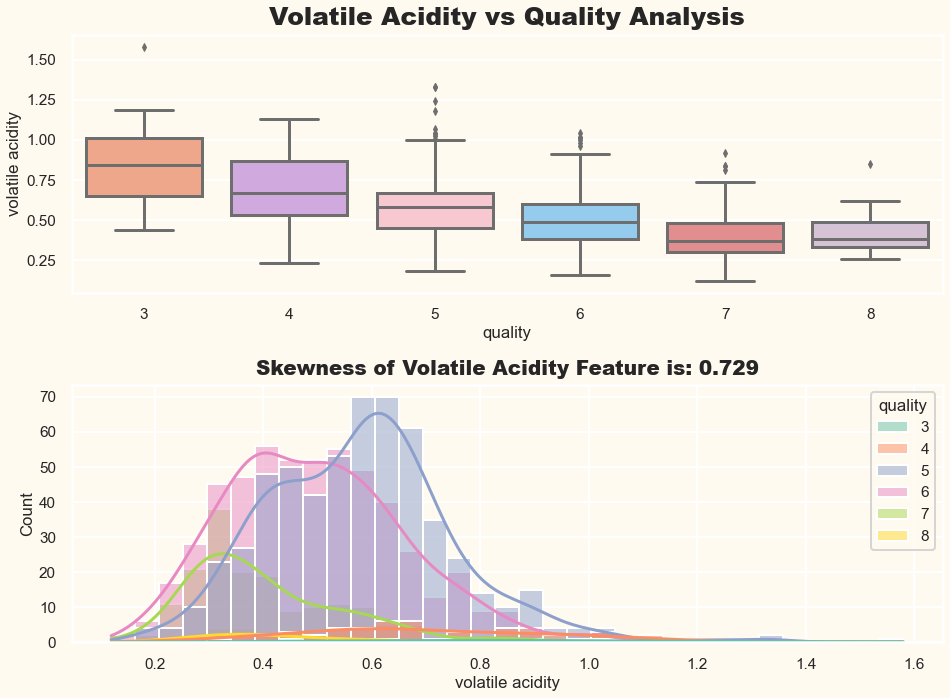

```python
numerical_plot("volatile acidity")
```

### 💬 Inference:

- The feature **Volatile Acidity** is having **almost a symmetric distribution** but the distribution is **right skewed** with a skewness value of **0.729**..
- Skewness can lead to several implications like **model performance**, **hypothesis testing** and it returns **biased estimation.**
- So we will use **tranformation techniques** to transform thesse feature to have a **symmetric distribution.**

## 4. Visualizing "Citric Acid" Attribute.

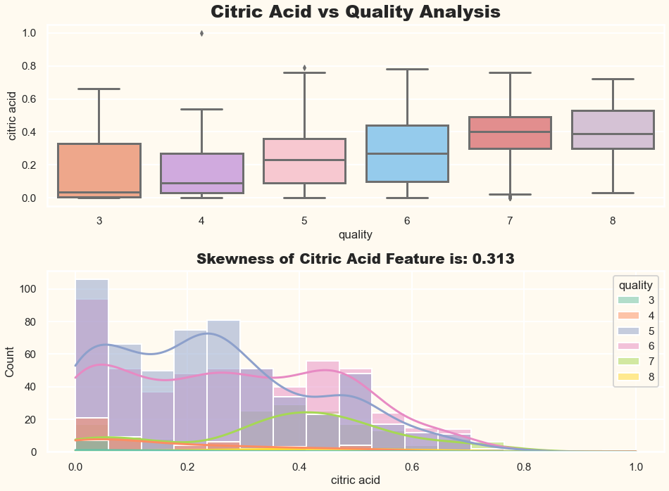

```python
numerical_plot("citric acid")
```

### 💬 Inference:

- The feature **Citric Acid** is having a distribution of **right skewed** with a skewness value of **0.313**.
- Although the **skewness is low** but still we try to bring the **skewness close to 0.**
- So we will use **tranformation techniques** to transform thesse feature to have a **symmetric distribution.**

## 5. Visualizing "Residual Sugar" Attribute.

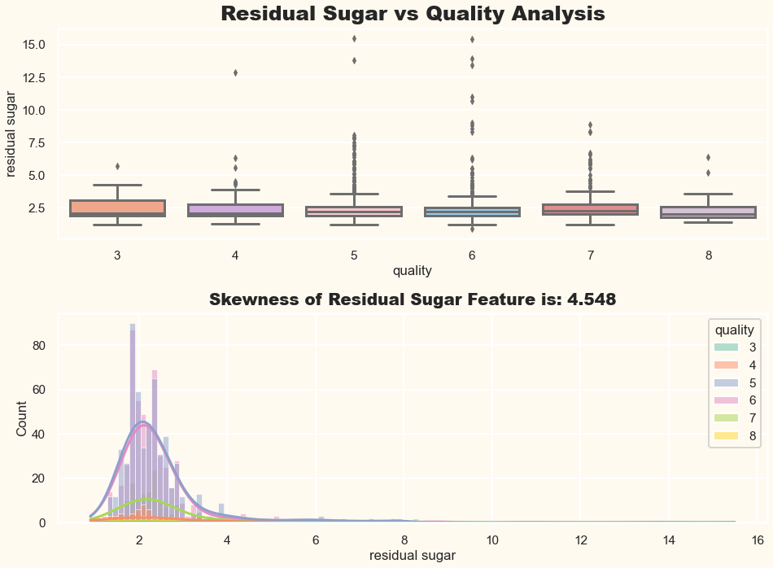

```python
numerical_plot("residual sugar")
```

## 6. Visualizing "Chlorides" Attribute.

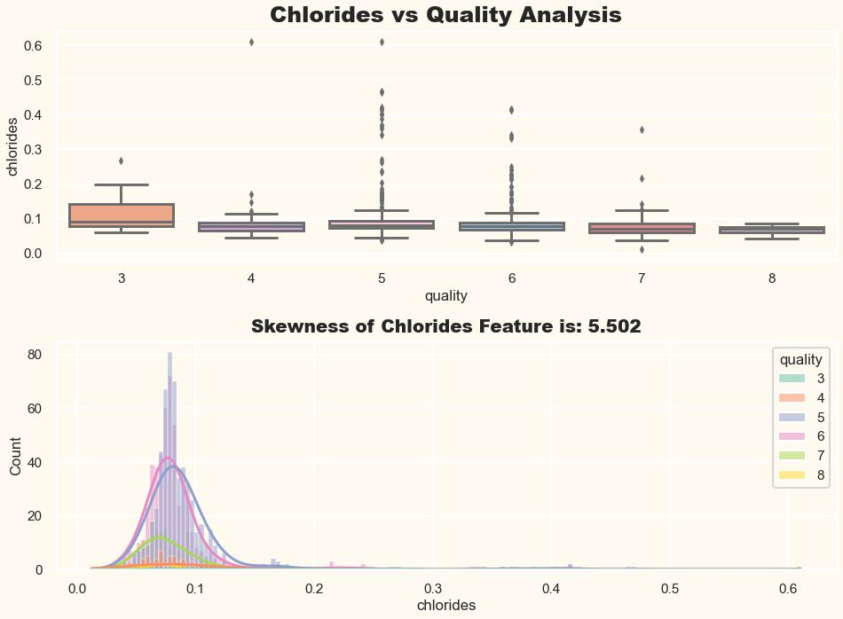

```python
numerical_plot("chlorides")
```

## 7. Visualizing "Free Sulfur Dioxide" Attribute.

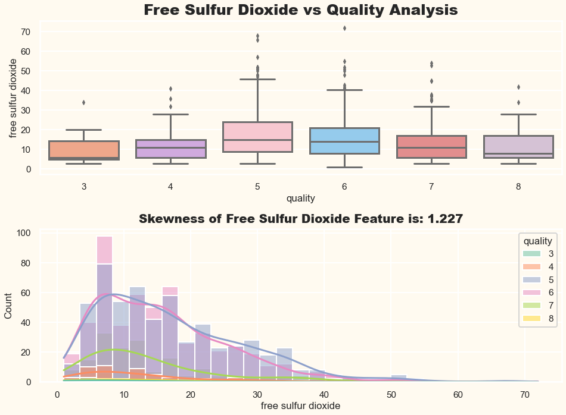

```python
numerical_plot("free sulfur dioxide")
```

### 💬 Inference:

- The feature **Free Sulfur Dioxide** is having a **highly right skewed distribution** with a skewness value of **1.227**..
- The distrbution is **highly right skewed** because of presence of **outliers.**
- So we will use **tranformation techniques** to transform thesse feature to have a **symmetric distribution** and bring **skewness close to 0.**

## 8. Visualizing "Total Sulfur Dioxide" Attribute.

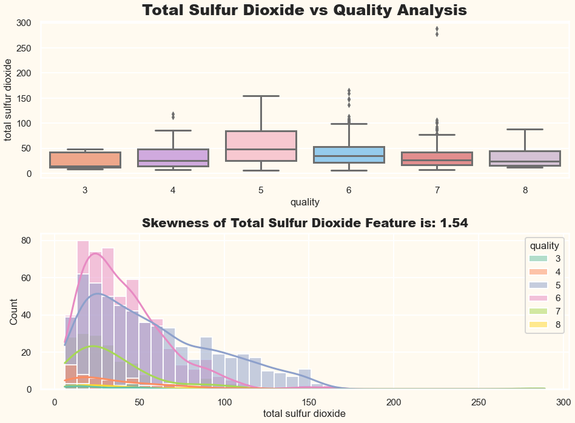

```python
numerical_plot("total sulfur dioxide")
```

### 💬 Inference:

- The feature **Total Sulfur Dioxide** is having a **highly right skewed distribution** with a skewness value of **1.54**.
- The distrbution is **highly right skewed** because of presence of **outliers.**
- So we will use **tranformation techniques** to transform thesse feature to have a **symmetric distribution** and bring **skewness close to 0.**

## 9. Visualizing "Density" Attribute.

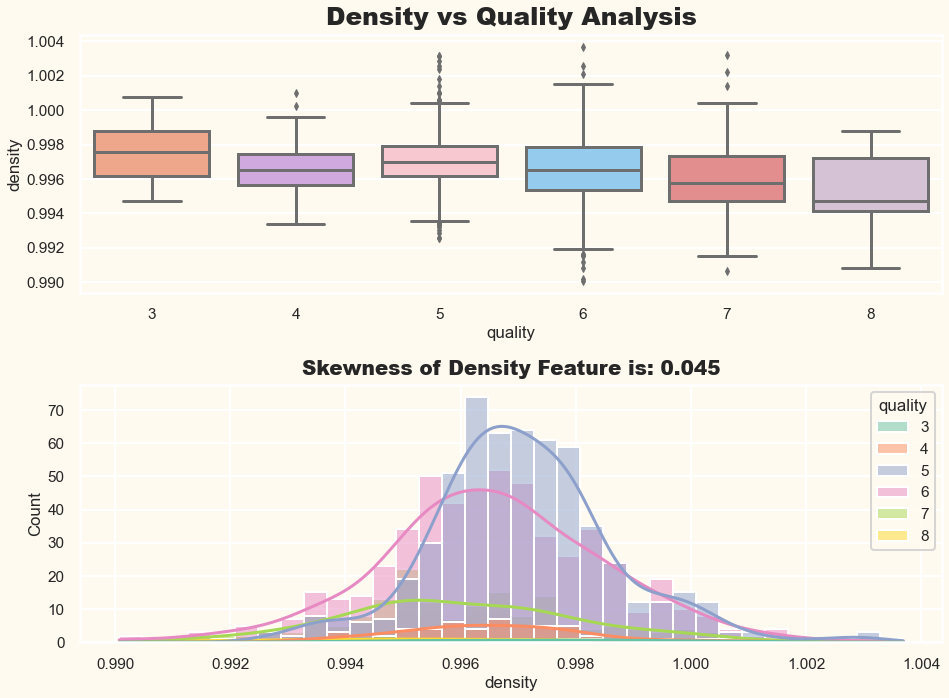

```python
numerical_plot("density")
```

### 💬 Inference:

- The feature **Density** is having a perfect **Noraml Distribution** because the **skewness is close to 0**.
- So we **don't** have to use aany transformation techniques on this feature.

## 10. Visualizing "pH" Attribute.

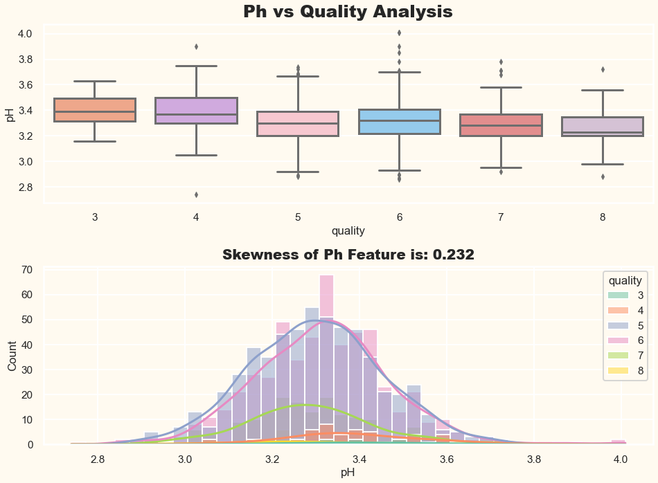

```python
numerical_plot("pH")
```

### 💬 Inference:

- The feature **pH** is having a **Normal Distribution** with a skewness value of **0.232**..
- But still the **tails** is little **right skewed** because of presence of **outliers.**
- So we will use **transformation techniques** to deal with those outliers.

## 11. Visualizing "Sulphates" Attribute.

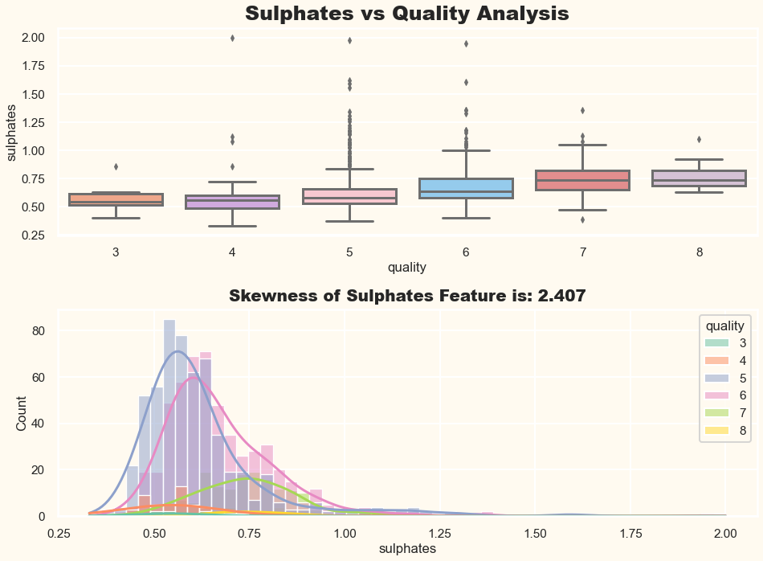

```python
numerical_plot("sulphates")
```

## 12. Visualizing "Alcohol" Attribute.

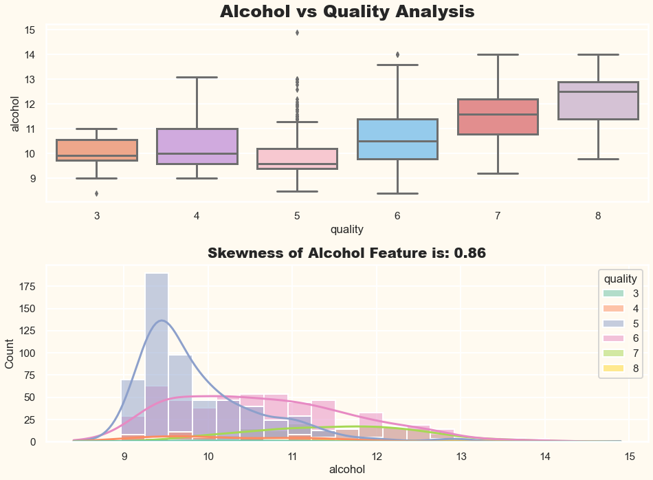

```python
numerical_plot("alcohol")
```

### 💬 Inference:

- The feature **Alcohol** is having **Asymmetric Distribution** and the distribution is **highly right skewed** with a skewness value of **0.86**.
- The distrbution is **highly right skewed** because of presence of **outliers.**
- So we will use **tranformation techniques** to transform thesse feature to have a **symmetric distribution** and bring **skewness close to 0.**